# Two HRS Core cognitive classification methods informed by HRS/HCAP

Rich Jones and Doug Tommet for HRS/HCAP Working Group

2026-10-22

## Contents

- Three classification algorithms: Manly-Jones (HCAP), HRS core, PMM
- HRS core algorithm: steps, decision rules, factor model
- PMM: steps, model, parameters, class probabilities
- Results: classification margins and agreement
- Limitations and next steps
- Summary
- Back-up slides

## Key terms: three algorithms

[output not shown]

## Manly-Jones algorithm

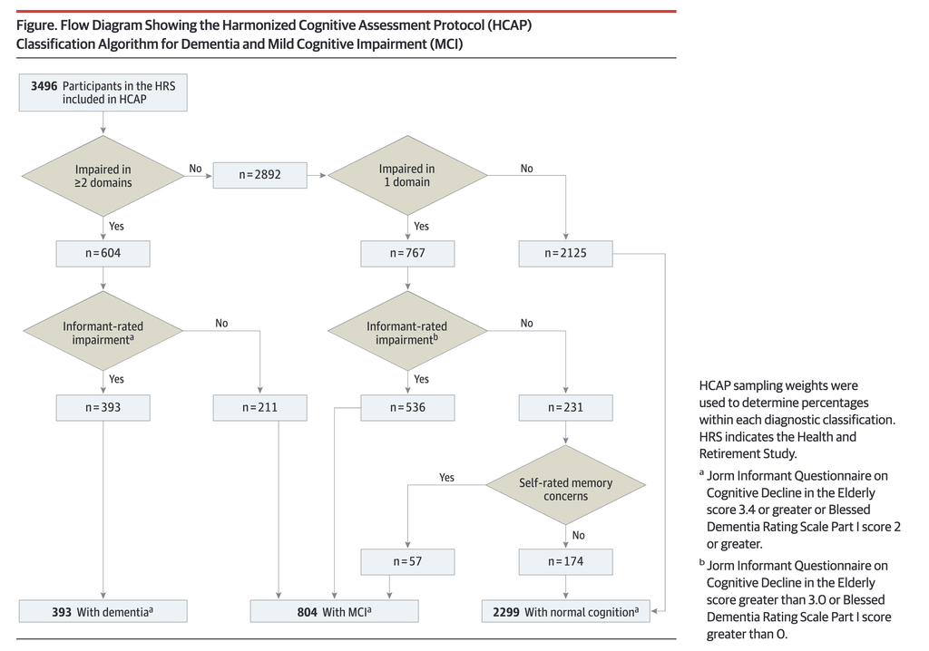

Source: Manly et al. (2022), JAMA Neurology, 79(12), 1242-1249.

## HRS core algorithm: steps

1. **One cognition score.** Fit a single-factor model (CFA) to the 8 core cognitive tests in HRS 2016 respondents aged 65 or older (N = 9,218), with HRS-HCAP weights.
2. **Demographic norms.** Compare each factor score with the score expected for a person of the same age, sex, race, ethnicity, and education in the HRS-HCAP robust norms group (n = 1,787). The result is a T score (mean 50, SD 10 in the norms group).
3. **Cut points.** Choose 2 T-score cut points ($\tau_1$ = 39, $\tau_2$ = 48) by a rule fixed before any result was seen: match the weighted Manly-Jones dementia and MCI shares, then take the highest weighted dementia kappa.
4. **Classify.** Combine the T-score range with self-rated memory (worse than 2 years ago). Respondents with no T score (proxy interviews) are classified by the informant IQCODE.
5. **Apply.** Hold every 2016 parameter fixed and classify core respondents in 2016, 2018, 2020, and 2022.

## HRS core algorithm

[figure not shown]

T: demographically adjusted T score from the 8 core cognitive tests, rounded to an integer. Cut points: $\tau_1$ = 39 and $\tau_2$ = 48, selected by a rule fixed before any result was seen (match the weighted Manly-Jones dementia and MCI shares, then highest weighted dementia kappa). IQCODE cut points for respondents with no test score: 3.0 and 3.4. Details in Appendix 1.

## HRS core algorithm: factor model

| Item | Loading, MLR (used for scoring) | Loading, WLSMV |
| --- | --- | --- |
| Orientation to date | 0.48 | 0.52 |
| Animal naming | 0.60 | 0.63 |
| Object naming (scissors, cactus) | 0.68 | 0.84 |
| Naming the President and Vice President | 0.60 | 0.64 |
| Delayed word recall | 0.63 | 0.64 |
| Number series | 0.71 | 0.62 |
| Serial 7 subtraction | 0.66 | 0.60 |
| Backward counting from 20 | 0.52 | 0.56 |

Single-factor model of the 8 core cognitive tests, HRS 2016 respondents aged 65 or older (N = 9,218), HRS-HCAP weights. Loadings are standardized (STDYX). WLSMV fit: RMSEA = 0.035, CFI = 0.966, TLI = 0.952, SRMR = 0.047. Guides for good fit: RMSEA below 0.05, CFI and TLI 0.95 or above, SRMR 0.08 or below. MLR (maximum likelihood) uses every available item response and gives the parameters used for scoring. Immediate word recall is left out because it adds little beyond delayed recall.

## PMM: steps

1. **Norms.** In the HRS-HCAP robust norms group, regress each core cognitive test on 24 sociodemographic terms. Fix these coefficients for every later step.
2. **Calibrate.** Fit a known-class model in HRS-HCAP: each participant’s class is fixed to the Manly-Jones class. The model estimates how the general cognitive factor and self-rated memory differ by class. Class proportions are fixed at the weighted Manly-Jones shares.
   - Cognition model: 3,283 participants with a test score or a memory self-rating
   - Informant model (IQCODE only): 213 participants without them
3. **Score.** Fix every parameter, release the class, and compute each person’s probability of Normal, MCI, and Dementia.
4. **Use the probabilities.** Average them for prevalence. The most likely class is available, but it under-counts MCI (back-up slide).
5. **Apply.** Score HRS Core respondents aged 65 or older in 2016, 2018, 2020, and 2022 with the fixed HRS-HCAP 2016 parameters.

## PMM: model

[figure not shown]

`cg` is the cognitive class (Normal, MCI, Dementia). In calibration it is fixed to the Manly-Jones class.

`GCP` is a general cognitive factor measured by the 8 core cognitive tests. Its mean and variance differ by class (Normal: mean 0, variance 1). The tests inform class only through GCP; their loadings, intercepts, and thresholds are equal across classes. Self-rated memory has class-specific thresholds.

`K` holds the fixed coefficients from the robust norms group: each test regressed on 24 sociodemographic terms (age, sex, race, ethnicity, education, and their interactions). They adjust the tests for demographics. They do not predict class.

Two models: a cognition model for the 3,283 participants with a test score or a self-rating of memory, and an informant model (Jorm IQCODE only) for the 213 without them.

GCP carries the correlation among the tests within each class. A model that treats the tests as independent counts the same evidence more than once.

## PMM: covariate adjustment

[figure not shown]

Each cognitive test is regressed on the sociodemographic terms in the HRS/HCAP robust norms group. The coefficients describe expected performance for a person free of conditions that affect cognition, the same norming step as the Manly-Jones algorithm.

Three methods give the same adjustment: a residual from the norms-group equation, an offset, or fixed regression coefficients.

The Manly-Jones algorithm uses residuals. The PMM uses fixed coefficients, because five of the eight core cognitive tests are ordinal (ordered categories), and residuals do not work for ordinal tests.

## PMM: standardized factor loadings by class

| Test | Loading on the general cognitive factor (STDYX) Normal | Loading on the general cognitive factor (STDYX) MCI | Loading on the general cognitive factor (STDYX) Dementia |
| --- | --- | --- | --- |
| Orientation to date | −0.32 | −0.28 | −0.45 |
| Animal naming | −0.28 | −0.31 | −0.40 |
| Object naming (scissors, cactus) | −0.44 | −0.37 | −0.38 |
| Naming the President and Vice President | −0.35 | −0.40 | −0.41 |
| Delayed word recall | −0.38 | −0.43 | −0.51 |
| Number series | −0.33 | −0.38 | −0.44 |
| Serial 7 subtraction | −0.32 | −0.35 | −0.44 |
| Backward counting from 20 | −0.26 | −0.30 | −0.31 |

## PMM: general cognitive factor by class

| Class | Mean (SE) | SD (SE) | Variance (SE) |
| --- | --- | --- | --- |
| Normal | 0 (fixed) | 1 (fixed) | 1 (fixed) |
| MCI | 1.39 (0.10) | 1.23 (0.11) | 1.51 (0.26) |
| Dementia | 3.04 (0.21) | 1.52 (0.19) | 2.31 (0.59) |

The Normal class sets the scale (mean 0, variance 1), so the MCI and Dementia means are in Normal-class SD units. The Dementia mean lies 3.0 SD above the Normal mean, and the MCI mean lies 1.4 SD above it. These are model estimates of the factor distribution in each class, not averages of individual factor scores. SD is the square root of the variance; its SE uses the delta method. PMM cognition model, known-class calibration in HRS-HCAP (N = 3,283).

## PMM: class probabilities

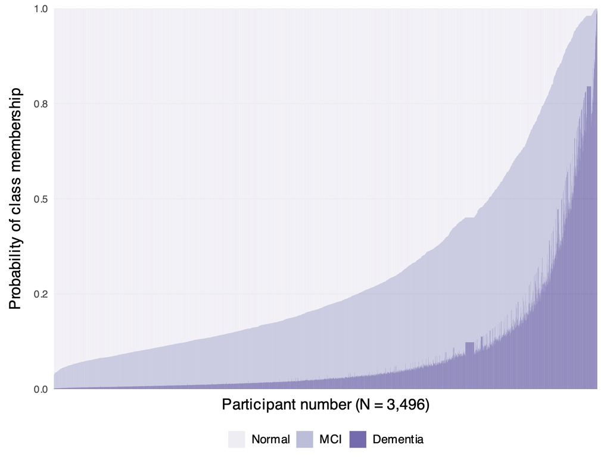

Each vertical bar is one HRS/HCAP participant, with the probabilities of Normal, MCI, and Dementia stacked. Participants are sorted by probability. The averaged probabilities and the most likely class assignments describe different aspects of classification (see the marginal-rate comparison in the manuscript tables).

## PMM: distribution of class probabilities

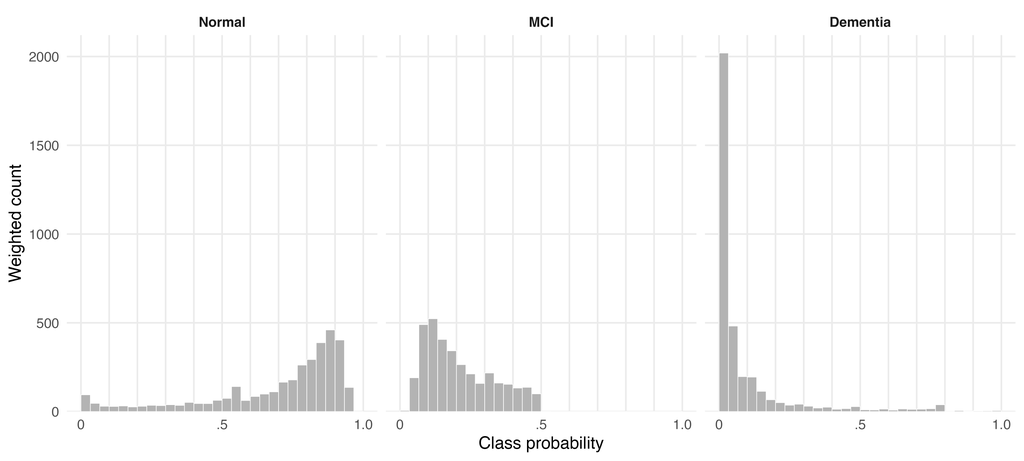

## Classification margins by method

[output not shown]

HRS/HCAP 2016 participants. N values are unweighted counts, except PMM probability allocation, where N is the expected count (sum of class probabilities). Weighted percentages use HCAP16WGTR. PMM most likely class assigns each person to the class with the highest probability; probability allocation splits each person across classes by their probabilities. Same values as Table 2 of the tables document.

## Agreement with the Manly-Jones algorithm

| Compared with Manly-Jones algorithm | N | Normal, MCI, Dementia (weighted kappa) | Dementia vs. no dementia (kappa) |
| --- | --- | --- | --- |
| Core algorithm | 3,496 | 0.50 | 0.34 |
| PMM | 3,496 | 0.37 | 0.31 |

HRS/HCAP 2016 participants. Kappa measures agreement beyond chance (0 = chance, 1 = perfect). The three-class kappa uses quadratic weights, so a Normal vs. MCI disagreement counts less than a Normal vs. Dementia disagreement. All kappas use HCAP population weights (HCAP16WGTR). Both the core algorithm and the PMM are calibrated and scored in the same sample, so their agreement is an in-sample estimate.

## Pairwise agreement among methods

|  | Manly-Jones algorithm | Core algorithm | PMM (probability allocation) | Langa-Weir | Hudomiet | Consensus diagnosis |
| --- | --- | --- | --- | --- | --- | --- |
| Manly-Jones algorithm | 1.000 | 0.501 | 0.373 | 0.510 | 0.551 | 0.728 |
| Core algorithm | 0.501 | 1.000 | 0.502 | 0.558 | 0.601 | 0.081 |
| PMM (probability allocation) | 0.373 | 0.502 | 1.000 | 0.433 | 0.448 | 0.139 |
| Langa-Weir | 0.510 | 0.558 | 0.433 | 1.000 | 0.717 | 0.099 |
| Hudomiet | 0.551 | 0.601 | 0.448 | 0.717 | 1.000 | 0.396 |
| Consensus diagnosis | 0.728 | 0.081 | 0.139 | 0.099 | 0.396 | 1.000 |

Three-class (Normal, MCI, Dementia) quadratic weighted kappa for each pair of methods, HRS/HCAP 2016 participants. The PMM row and column use probability allocation. Consensus comparisons use normalized HCAP16WGTR / samplingP weights; all others use HCAP16WGTR. Same values as Table 4 of the tables document.

## Limitations: HRS core algorithm

- **In-sample agreement.** The cut points were chosen in HRS-HCAP Wave 1, the same sample used to judge agreement, so agreement is optimistic. HRS-HCAP Wave 2 re-interviewees give an out-of-sample check.
- **Self-rated memory in place of an informant.** Many participants with low T scores did not report memory worsening, so the core algorithm likely under-classifies dementia relative to the Manly-Jones algorithm.
- **2018 has 7 tests.** Number series is missing in 2018, and the pattern of its missingness is hard to discern.
- **Interview mode and language.** The norms do not account for interview mode or language of administration, which vary across respondents and waves.
- **Different IQCODE windows.** The core IQCODE asks about change over 2 years; the HRS-HCAP IQCODE asks about change over 10 years.
- **Hard cut points on continuous scores.** Small changes in test performance can move a person across a cut point, which produces unstable classifications near the thresholds.

## Limitations: PMM

- **In-sample agreement.** The PMM is calibrated and evaluated in the same HRS-HCAP Wave 1 sample.
- **Fixed class proportions.** Scoring holds the class proportions at the HRS-HCAP 2016 values. In 2018 to 2022, prevalence can change only through test scores, and the fixed proportions pull uncertain cases toward the 2016 mix.
- **Model assumptions.** The tests relate to class only through the general factor (equal loadings, intercepts, and thresholds across classes), and the factor is normal within each class. If these assumptions fail, the probabilities are biased.
- **Most likely class misleads.** Assigning each person to their most likely class gives MCI 8.4%, against 21.4% for the Manly-Jones algorithm. Prevalence estimates need the probabilities.
- **Lower three-class agreement.** Kappa with the Manly-Jones algorithm is 0.37 for the PMM (probability allocation) and 0.50 for the core algorithm. Splitting each person across classes lowers kappa.
- **Same information limits as the core algorithm.** There is no informant report for self-respondents and no ADL or IADL items, and the informant model rests on the IQCODE alone, with its 2-year window.

## Next steps

- **Out-of-sample check.** Compare both methods with the Manly-Jones algorithm among HRS-HCAP Wave 2 re-interviewees.
- **Prevalence over time.** Compare 2016 to 2022 prevalence from the core algorithm and the PMM.
- **Guidance for users.** Set out when to use assigned classes and when to use class probabilities (for example, as weights or as repeated draws).
- **PMM sensitivity.** Let class proportions vary by wave, and test the assumption of equal test parameters across classes.
- **Manuscript.** Finish the manuscript and appendices, and update the files shared with collaborators.

## Summary

- Both core methods take their structure from the Manly-Jones algorithm: demographic adjustment set in a robust norms group, plus self-rated memory and informant data. Both use the same information (no ADL or IADL items, no immediate word recall).
- Agreement with the Manly-Jones algorithm, three classes: core algorithm 0.50; PMM 0.37.
- Agreement for dementia vs. no dementia: core algorithm 0.34; PMM 0.31.
- CAUTION: these agreement statistics are in-sample (HRS/HCAP used for derivation and evaluation of the core algorithm and the PMM).
- The PMM also gives each person a probability for each class, which carries classification uncertainty into later analyses.

Fin

# Back-up slides

## Back-up: why no ADL or IADL items?

| Manly-Jones class | n | Self-reported ADL or IADL limitations, 2016 core None, % | Self-reported ADL or IADL limitations, 2016 core 1, % | Self-reported ADL or IADL limitations, 2016 core 2 or more, % | Self-reported ADL or IADL limitations, 2016 core Missing, % |
| --- | --- | --- | --- | --- | --- |
| Normal | 2,256 | 84.0 | 8.8 | 7.2 | 0.0 |
| MCI | 744 | 68.7 | 14.2 | 17.1 | 0.0 |
| Dementia | 283 | 52.3 | 14.1 | 33.6 | 0.0 |

HRS-HCAP Wave 1 participants with a core T score (n = 3,283). Limitations counted on the 9 ADL and IADL items asked in every core wave from 2016 to 2022. Percentages are weighted (HCAP16WGTR). Appendix 1, Endnote and Table A9.

## Back-up: PMM probabilities vs. most likely class

|  | Weighted % Normal | Weighted % MCI | Weighted % Dementia | Difference from Manly-Jones (points) Normal | Difference from Manly-Jones (points) MCI | Difference from Manly-Jones (points) Dementia |
| --- | --- | --- | --- | --- | --- | --- |
| Manly-Jones algorithm | 69.4 | 21.4 | 9.2 | 0.00 | 0.00 | 0.00 |
| Core algorithm | 68.9 | 22.0 | 9.1 | −0.51 | 0.58 | −0.07 |
| PMM: mean probabilities | 69.7 | 21.2 | 9.1 | 0.30 | −0.19 | −0.11 |
| PMM: most likely class | 85.6 | 8.4 | 6.0 | 16.21 | −12.95 | −3.26 |

- Averaging the PMM probabilities reproduces the Manly-Jones class rates, because the model was calibrated to them.
- Taking each person’s most likely class does not. A person with probabilities of 0.55 Normal and 0.45 MCI counts as fully Normal. MCI carries a large share of the total probability but is rarely any one person’s most likely class, so MCI shrinks and Normal grows.
- Use the probabilities for prevalence and the most likely class only where a single label is needed.

Common comparison sample, N = 3,496; HCAP16WGTR. Same values as Table 2b of the tables document.

## Back-up: choosing the core cut points

- **Rule, fixed before any result was seen.** Among all pairs of integer cut points, keep those whose weighted dementia and MCI shares fall within 0.5 and 1.0 percentage points of the Manly-Jones shares. Among those, take the pair with the highest weighted dementia kappa.
- **Result.** 5 of 575 pairs qualified. The rule chose $\tau_1$ = 39 and $\tau_2$ = 48 (dementia kappa 0.34, three-class kappa 0.50).
- **Stability.** In 500 bootstrap samples drawn by the HRS sampling design, the rule chose the same pair in 8% and a pair within 1 point of both cut points in 50%.
- **Why the exact pair moves.** Next to the chosen cut points, a 1-point change in $\tau_1$ moves weighted dementia prevalence by 0.5 points, and a 1-point change in $\tau_2$ moves MCI prevalence by 0.9 points. Small sampling shifts can move a pair into or out of the qualifying set.

HRS-HCAP Wave 1 (n = 3,496). Appendix 1, Step 3.

## Back-up: core algorithm vs. Manly-Jones

| Manly-Jones class | Core: Normal | Core: MCI | Core: Dementia | Total |
| --- | --- | --- | --- | --- |
| Normal | 28,638 (82%) | 5,145 (15%) | 1,005 (3%) | 34,788 |
| MCI | 5,098 (48%) | 3,876 (36%) | 1,751 (16%) | 10,725 |
| Dementia | 794 (17%) | 1,995 (43%) | 1,831 (40%) | 4,620 |

- Of participants with dementia by the Manly-Jones algorithm, 40% have dementia by the core algorithm.
- Of participants with dementia by the core algorithm, 40% have dementia by the Manly-Jones algorithm.
- Kappa: three-class 0.50; dementia vs. not 0.34.

Cell entries are survey-weighted population counts in thousands. Entries for fewer than 1,000 persons show two significant digits. Row percentages in parentheses. N = 3,496 HRS-HCAP Wave 1 participants with both classifications (HCAP16WGTR). Appendix 1, Tables A4 and A5.